# Stockton Policing

Carlos Vasquez

12/7/21

===================== # STEP 1: Set up my environment # =====================

Notes: setting up my R environment by loading ‘tidyverse’ and [Stockton](https://openpolicing.stanford.edu/data/) data set.

```r
library(tidyverse)
library(lubridate)
library(janitor)
library(scales)
```

```r
stockton<-read.csv("ca_stockton_2020_04_01.csv")
```

===================== # STEP 2: Explore the data set # =====================

First, let’s take a look at what columns exist in our `stockton` data frame.

```r
colnames(stockton)
```

```
##  [1] "raw_row_number"   "date"             "division"         "subject_age"
##  [5] "subject_race"     "subject_sex"      "officer_id_hash"  "type"
##  [9] "arrest_made"      "citation_issued"  "warning_issued"   "outcome"
## [13] "search_conducted" "search_basis"     "reason_for_stop"  "raw_result"
## [17] "raw_search"
```

How many stops do we have in our dataset?

```r
nrow(stockton)
```

```
## [1] 41629
```

What date range does our data cover?

```
## [1] "2012-01-01"
```

to

```
## [1] "2016-12-31"
```

===================== # STEP 3. Clean the data # =====================

Our analyses is only relevant for traffic stops so lets make sure our data frame is applicable for such data

```r
 unique(stockton$type)
```

```
## [1] "vehicular"
```

===================== # STEP 4. Conduct descriptive analysis # =====================

To find stop counts per year, we need to define a notion of year (recall that our data only has date). Use the year() and mutate() functions to add a new column called year to our stops data frame and then use count() to determine the number of stops per year.

| year | n |
| --- | --- |
| 2012 | 2863 |
| 2013 | 7874 |
| 2014 | 7023 |
| 2015 | 14310 |
| 2016 | 9559 |

Use count() to determine the number of stops by race

| subject_race | n |
| --- | --- |
| asian/pacific islander | 3787 |
| black | 10870 |
| hispanic | 16573 |
| other | 1640 |
| white | 8553 |

Let’s make another table that gives us the proportion of stops by race.

| subject_race | n | prop |
| --- | --- | --- |
| asian/pacific islander | 3787 | 0.09142264 |
| black | 10870 | 0.26241460 |
| hispanic | 16573 | 0.40009174 |
| other | 1640 | 0.03959153 |
| white | 8553 | 0.20647949 |

This stat on is own, though, doesn’t actually say much. We’ll return to this more rigorously later on.

How about counting how many stops by year and race?

| year | subject_race | n |
| --- | --- | --- |
| 2012 | asian/pacific islander | 268 |
| 2012 | black | 624 |
| 2012 | hispanic | 1114 |
| 2012 | other | 156 |
| 2012 | white | 690 |
| 2013 | asian/pacific islander | 788 |
| 2013 | black | 1841 |
| 2013 | hispanic | 3193 |
| 2013 | other | 321 |
| 2013 | white | 1710 |

[output cut: 15 more lines]

Lets visualize

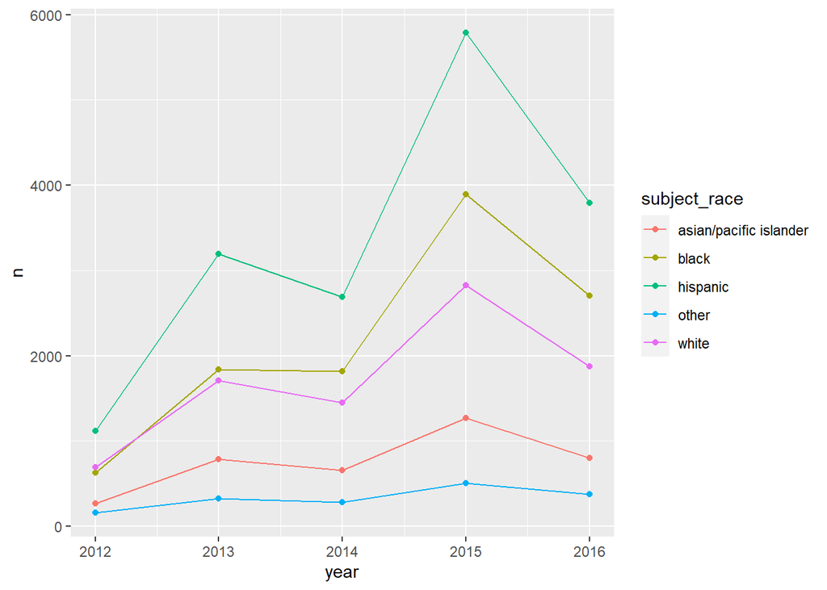

All groups experienced a spike in 2015. Lets look further and see what happened in that year.Filter out the data.

```r
df2015 <- stockton %>% filter(year(date) == 2015)
```

Look for racial demographics in Stockton (2015) i.e. number of hispanics, blacks, asian, etc. and create a data frame to establish comparison.

```r
population_2015 <- tibble(subject_race = c("asian/pacific islander","black", "hispanic", "other","white"),
  num_people = c(4272, 34772, 126048, 39432, 132471)) %>%
  mutate(subject_race = as.factor(subject_race))
```

Lets see our newly formed numbers and with proportion rates.

| subject_race | num_people | proportion |
| --- | --- | --- |
| asian/pacific islander | 4272 | 0.01267675 |
| black | 34772 | 0.10318254 |
| hispanic | 126048 | 0.37403522 |
| other | 39432 | 0.11701064 |
| white | 132471 | 0.39309485 |

Visualization

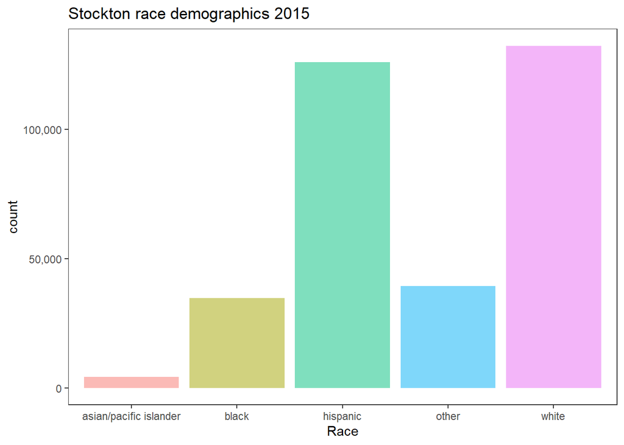

# ——————

If we join the two tables(population_2015 and df2015) together, we can compute stop rates by race i.e. number of stops per person (Note: Remember to take into account how many years are in your stop data, in order to get a true value of stops per capita; we’re using only 2015 for stops and for population, so we’re in good shape). Use mutate () to calculate the stop rate.

```r
df2015 %>%
  count(subject_race) %>%
  drop_na() %>%
  left_join(population_2015,by = "subject_race") %>%
  mutate(stop_rate = n / num_people)
```

| subject_race | n | num_people | stop_rate |
| --- | --- | --- | --- |
| asian/pacific islander | 1271 | 4272 | 0.29751873 |
| black | 3889 | 34772 | 0.11184286 |
| hispanic | 5787 | 126048 | 0.04591108 |
| other | 507 | 39432 | 0.01285758 |
| white | 2827 | 132471 | 0.02134052 |

| subject_sex | n | prop |
| --- | --- | --- |
| female | 4406 | 0.3083922 |
| male | 9881 | 0.6916078 |

Unfortunately, we don’t have a data frame to establish comparison of stop rates for sex but we can visualize the number of arrest by race and sex.

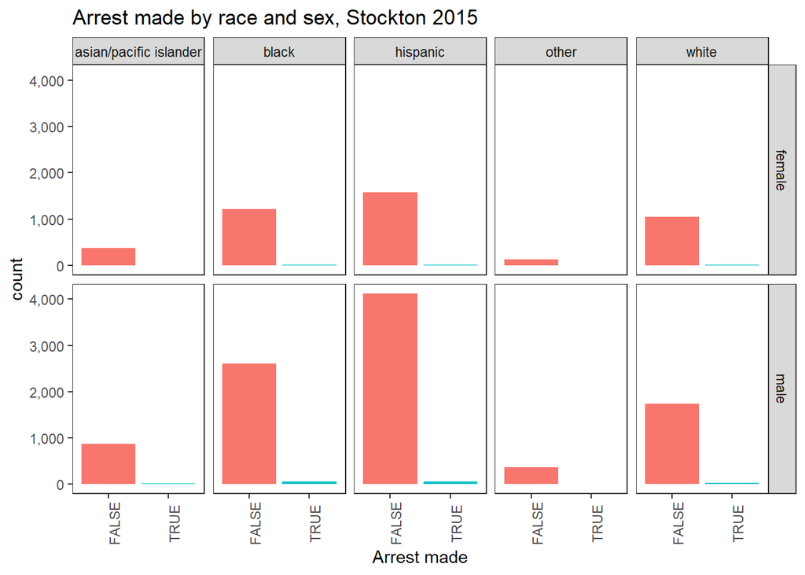

Males appear to outnumber females but without a baseline comparison we can not determine the difference in stop rates between males and females. However, a lot of the interaction did not result in an arrest. What were the outcomes?

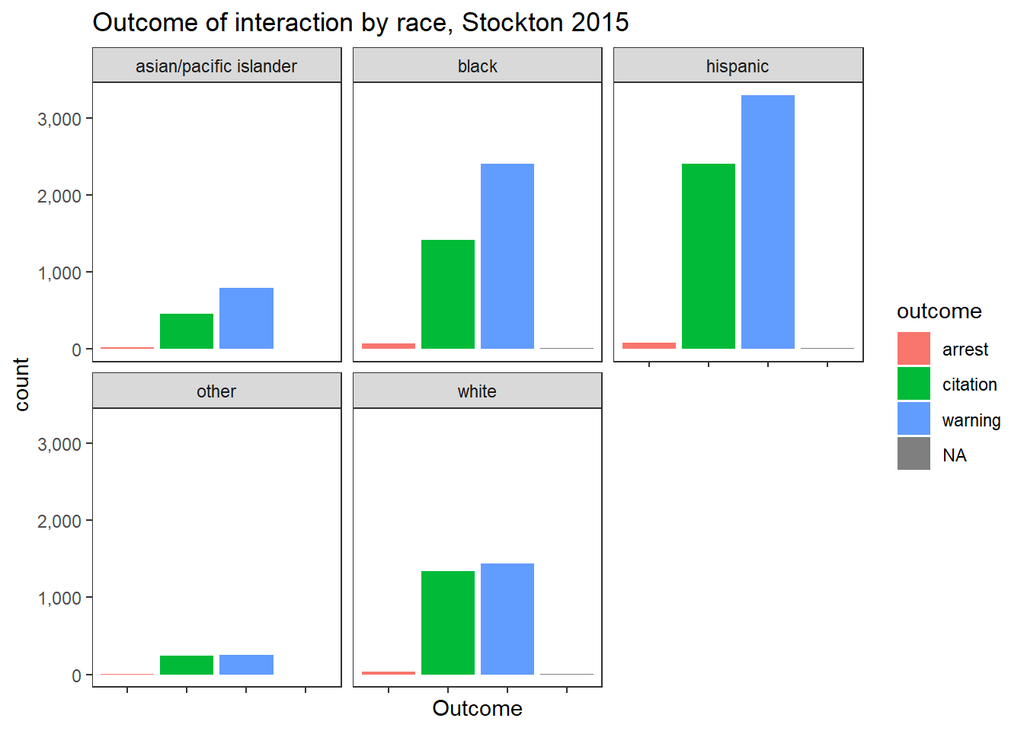

# ——————

| subject_race | search_rate | arrest_rate |
| --- | --- | --- |
| asian/pacific islander | 0.12352478 | 0.01811024 |
| black | 0.25224994 | 0.01800412 |
| hispanic | 0.18627959 | 0.01313288 |
| other | 0.07495069 | 0.01183432 |
| white | 0.11284047 | 0.01414927 |

Now let’s dive into these results. As with the stop rates, we can make a quantitative claim about disparities in search and frisk rates by dividing the minority rate by the white rate.

Here we see that among drivers who were stopped, black drivers were searched at a rate 2.2 times higher than white drivers, and Hispanic drivers were searched at a rate 1.6 times higher than white drivers.

This is all to say that while benchmark stats are a good place to start, more investigation is required before we can draw any conclusions that bias or discrimination is overtly present in Stockton law enforcement.